# Ayudantía N°1

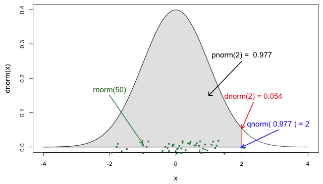

# Distribuciones

## Distribución Normal

La función *pnorm* calcula la función de distribución acumulativa (CDF) de una distribución normal en un valor específico x. En otras palabras, pnorm(x) te dará la probabilidad de que un valor aleatorio de una distribución normal sea menor o igual a x.

```r
pnorm(0)
```

```
## [1] 0.5
```

*dnorm* se utiliza para calcular la función de densidad de probabilidad (PDF) de una distribución normal en un punto dado. En otras palabras, dado un valor x, dnorm(x) te dará la altura de la curva de la distribución normal en ese punto.

```r
dnorm(0)
```

```
## [1] 0.3989423
```

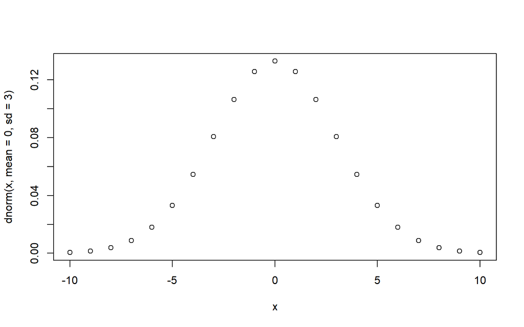

```r
x <- c(-10:10)
plot(x, dnorm(x, mean=0, sd=3))
```

La función *qnorm* es la inversa de pnorm. Dado un valor de probabilidad p, qnorm(p) te dará el valor x en la distribución normal tal que P(X ≤ x) = p.

```r
qnorm(0.5)
```

```
## [1] 0
```

La función *rnorm* se utiliza para generar números aleatorios que siguen una distribución normal. Puedes usar rnorm para generar una muestra aleatoria de valores que sigan una distribución normal con una media y desviación estándar específicas.

```r
rnorm(10)
```

```
##  [1]  0.202685659 -1.040918331 -0.331011253 -0.084716415  1.456994936
##  [6]  1.956461108 -0.271731885  0.009033642 -0.452748362  0.862662267
```

## Distribución Binomial

La distribución binomial es un concepto fundamental en estadísticas y probabilidad que describe el número de éxitos en un conjunto de ensayos independientes e idénticamente distribuidos (llamados “ensayos de Bernoulli”), donde cada ensayo tiene dos resultados posibles: éxito o fracaso.

La función *dbinom()* en R se utiliza para calcular la función de densidad de probabilidad (PDF) de la distribución binomial en un valor específico de éxitos.

La función de probabilidad de la distribución binomial se expresa como:

$$P(X = k) = \binom{n}{k} \cdot p^k \cdot
(1 - p)^{n - k}$$

Donde: - $X$ es el número de éxitos.

- $k$ es un valor específico de éxitos (0, 1, 2, …, n).
- $\binom{n}{k}$ es el coeficiente binomial, que representa el número de formas diferentes en que se pueden elegir $k$ éxitos de $n$ ensayos. Se calcula como $\binom{n}{k} = \frac{n!}{k! \cdot (n - k)!}$, donde $n!$ es el factorial de $n$.
- $p^k$ es la probabilidad de tener $k$ éxitos.
- $(1 - p)^{n - k}$ es la probabilidad de tener $n - k$ fracasos.

Suponga que hay 12 preguntas de selección múltiple en un test de estadística. Cada pregunta tiene 5 alternativas, y solo una de ellas es correcta. Calcular la probabilidad de obtener 4 o menos respuestas correctas si un estudiante cualquiera responde el test al azar.

```r
sum(dbinom(x = 0:4, size = 12, prob = 0.2))
```

```
## [1] 0.9274445
```

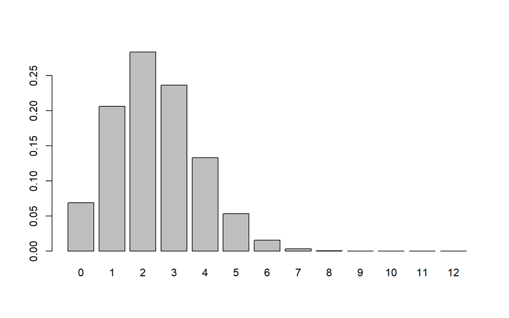

```r
barplot(dbinom(x = 0:12, size = 12, prob = 0.2), names.arg = 0:12)
```

¿Y utilizando la fórmula para *k* respuestas correctas?

$$P(X = k) = \binom{12}{k} \cdot (1/5)^k
\cdot (1 - 1/5)^{12 - k}$$

Recordar que:

$$\binom{n}{k} = \frac{n!}{k! \cdot (n -
k)!}$$

Por tanto:

$$\binom{12}{k} = \frac{12!}{k! \cdot (12
- k)!}$$

## Distribución Poisson

La distribución de Poisson es una distribución de probabilidad que modela el número de eventos que ocurren en un intervalo de tiempo o espacio dado, cuando estos eventos ocurren de manera aleatoria e independiente, pero con una tasa promedio conocida. Esa tasa se asume como $\lambda$.

$$P(X = k) = \frac{e^{-\lambda} \cdot
\lambda^k}{k!}$$

Donde: - $X$ es el número de eventos que queremos calcular la probabilidad.

- $k$ es el número de eventos específico (0, 1, 2, …) que estamos evaluando.
- $e$ es la base del logaritmo natural.
- $\lambda$ es la tasa promedio de ocurrencia de eventos en el intervalo.

La distribución de Poisson puede ser utilizada tanto para calcular probabilidades de cola izquierda como de cola derecha, dependiendo del contexto y del tipo de pregunta.

Si en promedio hay 12 autos por minuto cruzando un determinado puente, calcular la probabilidad de que 17 o más autos crucen el puente en un minuto cualquiera.

Nos piden $P(X≥17)=1−P(X<17)$

```r
1-ppois(16, lambda = 12)
```

```
## [1] 0.101291
```

```r
ppois(16, lambda = 12, lower.tail = FALSE)
```

```
## [1] 0.101291
```

Gráficamente:

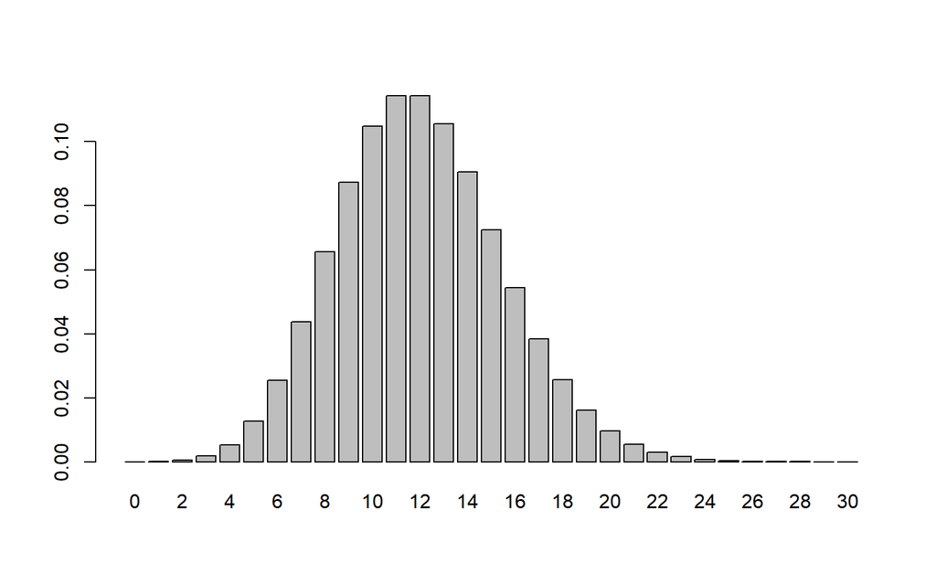

```r
barplot(dpois(x = 0:30, 12), names.arg = 0:30)
```

¿Y utilizando la fórmula?

# Esperanza, media y varianza

La **esperanza**, también conocida como valor esperado o media, es un concepto fundamental en estadística que representa el promedio ponderado de los posibles valores de una variable aleatoria. Se calcula multiplicando cada valor posible por su probabilidad de ocurrencia y luego sumando todos estos productos.

$$E(X) = \sum x_i \cdot P$$

La **media** es un término más general que se refiere al valor promedio de un conjunto de datos. Puede aplicarse tanto a datos determinísticos como aleatorios. Para calcular la media, simplemente sumamos todos los valores y dividimos entre el número total de valores.

$$\text{Media} = \mu = \frac{1}{n}
\sum_{i=1}^n x_i$$

La **varianza** mide la dispersión de los valores de una variable aleatoria con respecto a su media. Una varianza alta indica que los valores están más dispersos alrededor de la media, mientras que una varianza baja indica que los valores están más cerca de la media.

*La fórmula para calcular la varianza de una variable discreta es:*

$$\text{Varianza} = \frac{1}{n}
\sum_{i=1}^n (x_i - \text{Media})^2$$

Donde $x_i$ son los valores individuales, $\text{Media}$ es la media de los datos y $n$ es el número de datos.

*La fórmula para calcular la varianza de una variable continua es:*

$$\text{Varianza} = \int (x -
\text{Media})^2 \cdot f(x) \, dx$$

Donde $x$ es la variable continua, $\text{Media}$ es la media de la distribución y $f(x)$ es la función de densidad de probabilidad.

## Ejercicios

### Supongamos que lanzas un dado justo de seis caras. Calcula la esperanza, la media y la varianza de los resultados posibles.

```r
# Lanzar un dado justo de seis caras
resultados_dado <- 1:6

# Calcula la esperanza (media) de los resultados del dado
suma_valores <- sum(resultados_dado)
num_valores <- length(resultados_dado)
esperanza_dado <- suma_valores / num_valores

# Calcula la media de los resultados del dado
media_dado <- mean(resultados_dado)

# Calcula la varianza de los resultados del dado
varianza_dado <- mean((resultados_dado - esperanza_dado)^2)

esperanza_dado
```

```
## [1] 3.5
```

```r
media_dado
```

```
## [1] 3.5
```

```r
varianza_dado
```

```
## [1] 2.916667
```

Resultados posibles: 1, 2, 3, 4, 5, 6

Esperanza (media):
$$E(X) = \frac{1}{6}
\sum_{i=1}^6 x_i = \frac{1}{6} (1 + 2 + 3 + 4 + 5 + 6) = 3.5$$

Media:
$$\text{Media} = \frac{1}{6}
\sum_{i=1}^6 x_i = \frac{1}{6} (1 + 2 + 3 + 4 + 5 + 6) = 3.5$$

Varianza:
$$\text{Varianza} = \frac{1}{6}
\sum_{i=1}^6 (x_i - E(X))^2 = \frac{1}{6} \left( (1 - 3.5)^2 + (2 -
3.5)^2 + (3 - 3.5)^2 + (4 - 3.5)^2 + (5 - 3.5)^2 + (6 - 3.5)^2 \right) =
\frac{35}{12} \approx 2.917$$

La esperanza y la media son sinónimos, y ambos términos se utilizan para referirse al valor promedio de una variable aleatoria.

### Tienes los siguientes datos: 12, 15, 18, 22, 25. Calcula la media y la varianza de estos datos.

```r
# Datos
datos <- c(12, 15, 18, 22, 25)

# Calcula la media de los datos
media_datos <- mean(datos)

# Calcula la varianza de los datos
varianza_datos <- var(datos)

media_datos
```

```
## [1] 18.4
```

```r
varianza_datos
```

```
## [1] 27.3
```

Datos: 12, 15, 18, 22, 25

Media:
$$\text{Media} = \frac{1}{5}
\sum_{i=1}^5 x_i = \frac{1}{5} (12 + 15 + 18 + 22 + 25) = 18.4$$

### Para una distribución continua con función de densidad $f(x)=\frac{1}{2}e^{-x/2}$ y asumiendo $x≥0$ calcula la esperanza.

```r
# Función de densidad
f <- function(x) 0.5 * exp(-x/2)

# Calcula la esperanza (media) de la distribución
esperanza_distribucion_continua <- integrate(function(x) x * f(x), 0, Inf)$value

esperanza_distribucion_continua
```

```
## [1] 2
```

Distribución continua con función de densidad $f(x) = \frac{1}{2} e^{-x/2}$ para $x \geq 0$:

La esperanza de una variable aleatoria continua $X$ se calcula como:

$$E(X) = \int x \cdot f(x) \, dx$$

Sustituyendo la función de densidad dada:

$$E(X) = \int x \cdot \frac{1}{2}
e^{-x/2} \, dx$$

Aplicamos integración por partes, eligiendo $u = x$ y $dv = \frac{1}{2} e^{-x/2} \, dx$:

$$du = dx, \quad v = -e^{-x/2}$$

Usando la fórmula de integración por partes $\int u \, dv = uv - \int v \, du$:

$$E(X) = -\frac{1}{2} x e^{-x/2} +
\frac{1}{2} \int e^{-x/2} \, dx$$

La expresión resultante es:

$$E(X) = -\frac{1}{2} x e^{-x/2} +
\frac{1}{2} \int e^{-x/2} \, dx$$

Vamos a simplificarla paso a paso:

1. **Simplificar la expresión:**

   $$E(X) = -\frac{1}{2} x e^{-x/2} +
   \frac{1}{2} \int e^{-x/2} \, dx$$
2. **Simplificando la integral:**

   Utilizamos una sustitución $u = -\frac{x}{2}$, entonces $du = -\frac{1}{2} dx$.

   $$\int e^{-x/2} \, dx = -2 \int e^u \, du
   = -2 e^u + C = -2 e^{-x/2} + C$$
3. **Reemplazando en la expresión original:**

   $$E(X) = -\frac{1}{2} x e^{-x/2} +
   \frac{1}{2} (-2 e^{-x/2} + C) = -\frac{1}{2} x e^{-x/2} - e^{-x/2} +
   \frac{C}{2}$$

Por lo tanto, la expresión simplificada para $E(X)$ es:

$$E(X) = -\frac{1}{2} x e^{-x/2} -
e^{-x/2} + \frac{C}{2}$$

Evaluamos en los límites $0$ y $+\infty$:

$$E(X) = \lim_{{x \to +\infty}} \left(
-\frac{1}{2} x e^{-x/2} - e^{-x/2} \right) - \left( -\frac{1}{2} \cdot 0
\cdot e^{-0/2} - e^{-0/2} \right)$$

Por lo tanto, la esperanza (valor esperado) de la variable aleatoria $X$ es $2$.

#### Aparte: Límite de una Función cuando $x$ tiende a Infinito

Función dada: $E(X) = -\frac{1}{2} x e^{-x/2} - e^{-x/2}$

Queremos encontrar: $\lim_{x \to \infty} E(X)$

Factorizamos $e^{-x/2}$ de la expresión:
$$E(X) = e^{-x/2} \left(
-\frac{1}{2} x - 1 \right)$$

Ahora nos enfocamos en el término dentro del paréntesis: $-\frac{1}{2} x - 1$. A medida que $x$ tiende a infinito, $-\frac{1}{2} x$ se volverá un número negativo muy grande y -1 es una constante. Por lo tanto, $-\frac{1}{2} x - 1$ tenderá hacia menos infinito.

A medida que $x$ tiende a infinito, $e^{-x/2}$ tiende a 0 debido a que las funciones exponenciales con exponentes negativos decrecen rápidamente hacia cero a medida que el exponente crece.

Concluyendo, cuando $x$ tiende a infinito:
$$E(X) = e^{-x/2} \left(
-\frac{1}{2} x - 1 \right) \to 0 \cdot (-\infty) = 0$$

Por lo tanto, el límite de $E(X)$ cuando $x$ tiende a infinito es 0.

Matemáticamente:
$$\lim_{x \to \infty}
E(X) = 0$$